# *ASSIGNMENT 2: ANSWER SCRIPT*

**Load the following Packages**

```r
library(readxl)
library(tidyverse)
library(dplyr)
library(ggpubr)
```

*Importing and viewing the dataset*

```r
Assignment2_dataset <- read_excel(("C:/Users/DELL/Desktop/RAssignment2/Assignment2_dataset.xlsx"))
View(Assignment2_dataset)
```

## **Question 1**

**The missing values are removed ussing the two functios shown below**

```r
Assignment2_New <- na.omit(Assignment2_dataset)
```

### OR

```r
Assignment2_New <- na.exclude(Assignment2_dataset)
```

## **Question 2**

*Show relationship between prices and perceptions* *define values for perception* *compute the percentage of each perception that characterize our responses to price.*

```r
Positive <- ((length(c(Assignment2_New$P[Assignment2_New$P == "Positive"])))/(length(c(Assignment2_New$P))))*100
Negative <- ((length(c(Assignment2_New$P[Assignment2_New$P == "Negative"])))/(length(c(Assignment2_New$P))))*100
Somewhat_Positive <- ((length(c(Assignment2_New$P[Assignment2_New$P == "SP"])))/(length(c(Assignment2_New$P))))*100
Somewhat_Negative <- ((length(c(Assignment2_New$P[Assignment2_New$P == "SN"])))/(length(c(Assignment2_New$P))))*100
No_Response <- ((length(c(Assignment2_New$P[Assignment2_New$P == "NR"])))/(length(c(Assignment2_New$P))))*100
```

### covariation between perception and price

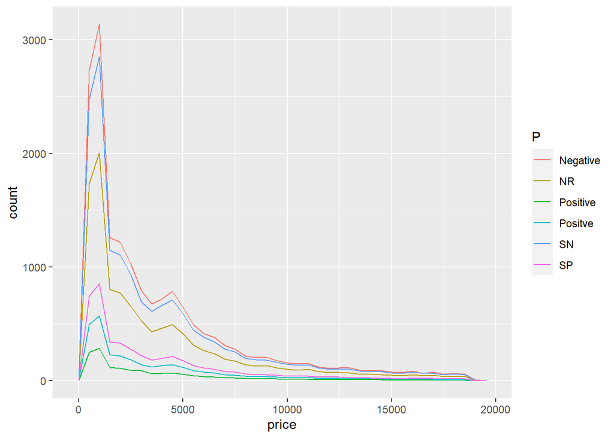

```r
ggplot(data = Assignment2_New, mapping = aes(x = price)) +
  geom_freqpoly(mapping = aes(color = P), binwidth = 500)
```

## **Question3**

*Comparing perception change(PC) and diamond quality (cut)*

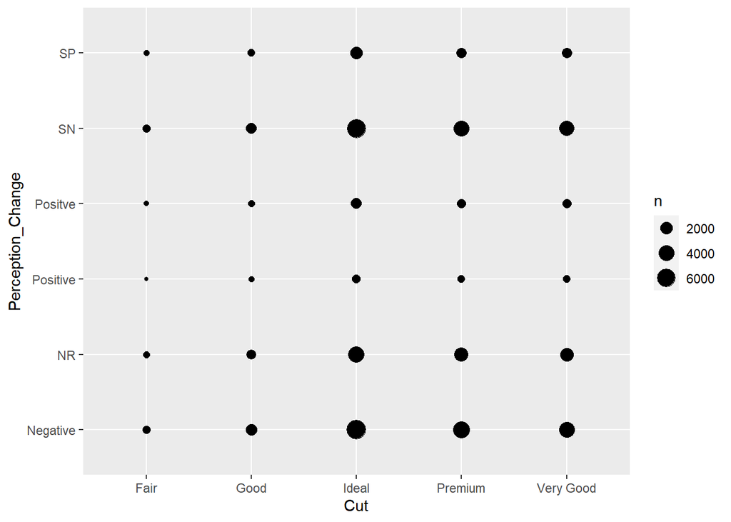

```r
# **covariation between perception change and diamond quality**
Perception_Change <- Assignment2_New$PC
Cut <- Assignment2_New$cut
ggplot(data = Assignment2_New) +
  geom_count(mapping = aes(x = Cut, y = Perception_Change))
```

## **Question 4**

# *A boxplot of all the variables*

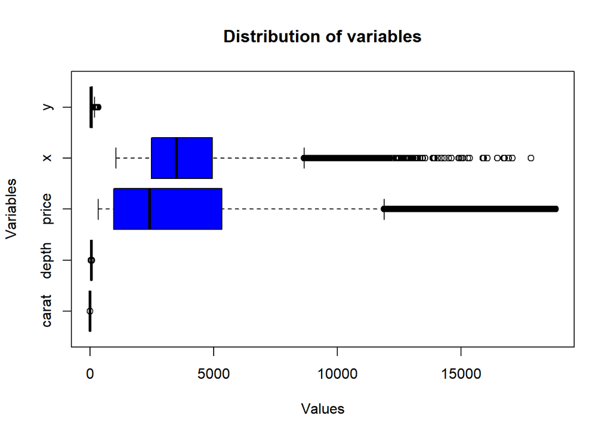

```r
boxplot(Assignment2_New$carat, Assignment2_New$depth, Assignment2_New$price, Assignment2_New$x, Assignment2_New$y, names=c("carat", "depth","price", "x", "y"), horizontal=TRUE, col="blue", main="Distribution of variables", xlab="Values", ylab="Variables")
```

*OR ,you can generate individual box plots to better view the outliers for each variable.* *Below is one of such examples*

```r
boxplot(Assignment2_New$carat)
```

## **Question5**

### **using the IQR method**

*calculate the quartiles for price*

```r
quartileprice <- quantile(Assignment2_New$price, probs=c(.25, .75), na.rm = FALSE)
quartileprice
```

```
##     25%     75%
##  949.25 5325.75
```

*calculate the upper and lower limits*

```r
pricelower <- quartileprice[1] - 1.5*IQRprices
priceupper <- quartileprice[2] + 1.5*IQRprices
pricelower
```

```
##     25%
## -5615.5
```

```r
priceupper
```

```
##     75%
## 11890.5
```

```r
price_no_outliers <- subset(Assignment2_New, Assignment2_New$price > priceupper | Assignment2_New$price < pricelower)
price_no_outliers
```

```
## # A tibble: 3,535 × 11
##       ID carat cut       colour clarity depth price      x     y P        PC
##    <dbl> <dbl> <chr>     <chr>  <chr>   <dbl> <dbl>  <dbl> <dbl> <chr>    <chr>
##  1 23826  1.54 Premium   F      SI1      60.9 11897  7725.  195. NR       NR
##  2 23827  2    Premium   J      SI2      61.9 11899  5950.  192. NR       NR
##  3 23828  2    Premium   J      SI2      59.8 11899  5950.  199. Negative Negat…
##  4 23829  1.56 Premium   F      SI1      60.7 11901  7629.  196. Positive Posit…
##  5 23830  2.01 Premium   F      SI2      62   11903  5922.  192. Positve  Posit…
##  6 23831  1.52 Very Good H      VVS2     63   11904  7832.  189. NR       NR
##  7 23832  1.27 Premium   F      VVS2     61.3 11905  9374.  194. NR       NR
##  8 23833  1.18 Ideal     E      VVS2     61.5 11906 10090.  194. SP       SP
##  9 23834  1.52 Very Good H      VS1      63.5 11912  7837.  188. SN       SN
## 10 23835  1.2  Very Good F      VVS1     59.8 11913  9928.  199. SN       SN
## # … with 3,525 more rows
```

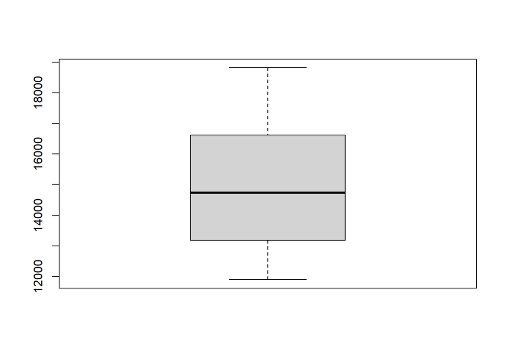

```r
boxplot(price_no_outliers$price)
```

*saving the new dataframe with no outliers*

```r
Dataset <- Assignment2_New[Assignment2_New$price < priceupper & Assignment2_New$price > pricelower,]
```

## **Question 6**

** creating a new csv **

```r
write.csv(Dataset, file="C:/Users/DELL/Desktop/A94166/Moga_Muzamil.csv")
```

## **Question 7**

```r
ggplot(Dataset, aes(x=cut, y=depth)) + geom_bar(stat="identity", fill="red") + labs(title="Relationship between the cut and the depth", x="Cut", y="depth")
```

[output not shown]

## **Question 8**

```r
mean(Dataset$carat,  na.rm = TRUE)
median(Dataset$carat,  na.rm = TRUE)
```

[output not shown]

### OR

*Q-Q plots draw the correlation between a given sample and the normal distribution.*

```r
ggqqplot(Dataset$carat, ylab = "Diamond carat",
         ggtheme = theme_minimal())
```

[output not shown]

### wilcoxon test on carat

```r
res <- wilcox.test(Dataset$carat, mu = 0) #mu is theoretical mean (0)
```

## **QUESTION 9**

```
## # A tibble: 50,395 × 3
##    carat PC       price
##    <dbl> <chr>    <dbl>
##  1  0.23 Negative   326
##  2  0.21 Negative   326
##  3  0.23 Negative   327
##  4  0.29 Negative   334
##  5  0.31 Negative   335
##  6  0.24 Negative   336
##  7  0.24 Negative   336
##  8  0.26 Negative   337
##  9  0.22 Negative   337
## 10  0.23 Negative   338
## # … with 50,385 more rows
```

```
## # A tibble: 100 × 3
##    carat PC       price
##    <dbl> <chr>    <dbl>
##  1  1    NR        9740
##  2  1    Positve   3696
##  3  0.5  Positive  1231
##  4  0.53 Negative  1284
##  5  1.2  Negative  5221
##  6  1    NR        3975
##  7  0.26 Negative   545
##  8  1.08 Negative  4481
##  9  1.51 NR       10655
## 10  0.9  SN        2729
## # … with 90 more rows
```

```
##   [1] NR       Positve  Positive Negative Negative NR       Negative Negative
##   [9] NR       SN       NR       Negative Positve  SN       Negative Positve
##  [17] Negative NR       Negative SN       Positve  Negative NR       Negative
##  [25] SN       Negative Positve  SN       SN       Negative Negative NR
##  [33] Negative Negative SN       SN       Negative NR       Positve  SN
##  [41] Negative NR       SN       Positive Negative Negative Negative SN
##  [49] Negative NR       SN       Negative Negative Negative Negative NR
##  [57] NR       Positve  SN       NR       SP       NR       NR       Negative
##  [65] Negative NR       SN       NR       SP       NR       NR       SN
##  [73] Positive Positve  SN       SN       Positve  Negative SP       SN
##  [81] NR       Negative Negative NR       SN       Negative Negative Negative
##  [89] NR       Negative Negative SN       SN       SN       Negative Negative
##  [97] NR       SN       Positve  SN
## Levels: Negative NR Positive Positve SN SP
```

```
## [1] "Negative" "NR"       "Positive" "Positve"  "SN"       "SP"
```

```
## # A tibble: 6 × 4
##   PC        mean    sd     n
##   <chr>    <dbl> <dbl> <int>
## 1 Negative 3148. 2772. 16298
## 2 NR       3164. 2760. 10399
## 3 Positive 3140. 2746.  1502
## 4 Positve  3153. 2769.  2962
## 5 SN       3172. 2767. 14786
## 6 SP       3172. 2764.  4448
```

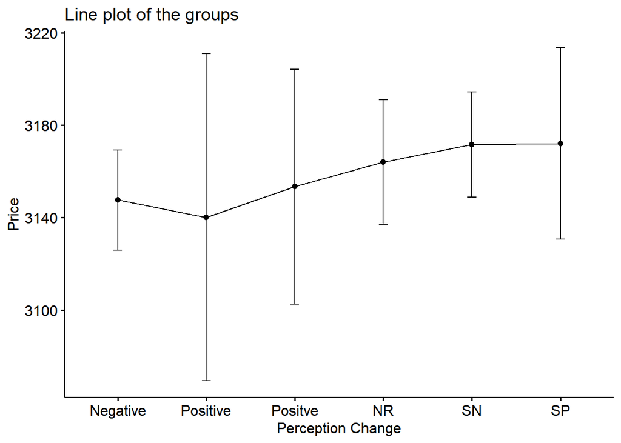

# Compute the varience.

```
##                Df    Sum Sq Mean Sq F value Pr(>F)
## PC              5 6.037e+06 1207379   0.158  0.978
## Residuals   50389 3.856e+11 7652503
```

# **Question 9b**

```r
TukeyHSD(anova, conf.level = .95)
```

```
##   Tukey multiple comparisons of means
##     95% family-wise confidence level
##
## Fit: aov(formula = price ~ PC, data = groups)
##
## $PC
##                          diff        lwr      upr     p adj
## NR-Negative        16.3983832  -82.54119 115.3380 0.9970896
## Positive-Negative  -7.5498297 -220.12357 205.0239 0.9999985
## Positve-Negative    5.7930631 -151.66692 163.2530 0.9999982
## SN-Negative        24.0120849  -65.51979 113.5440 0.9734305
## SP-Negative        24.4746307 -108.88346 157.8327 0.9952868
## Positive-NR       -23.9482129 -241.55012 193.6537 0.9995977
## Positve-NR        -10.6053201 -174.79010 153.5795 0.9999710
## SN-NR               7.6137017  -93.27710 108.5045 0.9999372
## SP-NR               8.0762476 -133.15894 149.3114 0.9999841
## Positve-Positive   13.3428928 -236.36733 263.0531 0.9999887
## SN-Positive        31.5619147 -181.92698 245.0508 0.9983151
## SP-Positive        32.0244605 -203.23270 267.2816 0.9988682
## SN-Positve         18.2190219 -140.47427 176.9123 0.9995053
## SP-Positve         18.6815677 -168.27293 205.6361 0.9997493
## SP-SN               0.4625458 -134.34953 135.2746 1.0000000
```

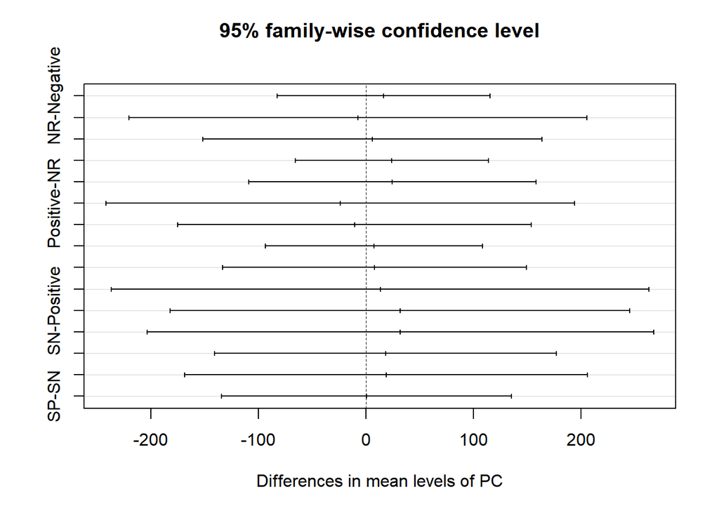

```r
plot(TukeyHSD(anova, conf.level = .95))
```